# Explore Weather Trends

### 1. Extracting data from database using SQL.

/ *This query is to identify my closest city.*/

SELECT * FROM city_list WHERE country in '%United States%' AND city like '%New York%'

/ *This query is to identify the average temperaty for each city*/

SELECT * FROM city_data WHERE city LIKE '%New York%'

/ *This query is to identify the average global temperatures by year*/

SELECT * FROM global_data

/ *This query gets Average temperature from Local Munich, Germany* /

SELECT * FROM city_data WHERE city LIKE '%Munich%'

### Global Data

```python
import pandas as pd
from ggplot import *
import matplotlib
```

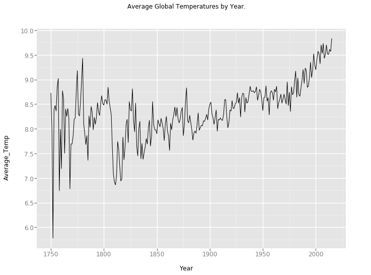

```python
#READ CSV for GLOBAL
global_data=pd.read_csv('global_data.csv')

##Checking the amount of value that is null
global_data['avg_temp'].isnull().sum().any()

#Cheking the number of count
global_data['avg_temp'].count()

# Renaming the column names to reduce confusions
global_data=global_data.rename(columns={'avg_temp':'avg_temp_GL'})

#plot the Global_Data
norm =ggplot(global_data, aes(x='year' ,y='avg_temp_GL')) + geom_line() \
    + ggtitle('Average Global Temperatures by Year.') + xlab('Year') + ylab('Average_Temp')

print norm
```

### Moving Average for global_data

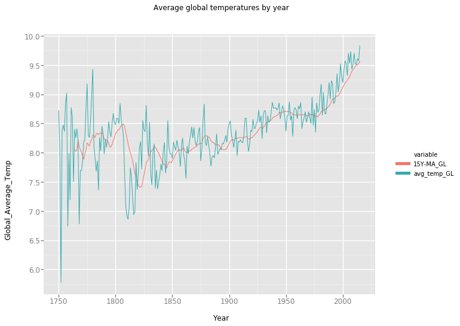

```python
# Moving Average.

#Identifying which moving average best smooth from the actual
# global_data["5Y-MA"]=pd.rolling_mean(global_data['avg_temp'],window=5)
global_data["15Y-MA_GL"]=pd.rolling_mean(global_data['avg_temp_GL'],window=15)
# global_data["20Y-MA"]=pd.rolling_mean(global_data['avg_temp'],window=20)
# global_data["30Y-MA"]=pd.rolling_mean(global_data['avg_temp'],window=30)
# global_data["50Y-MA"]=pd.rolling_mean(global_data['avg_temp'],window=50)

#melting the dataset so all variables can appear on on single plot
new_df=pd.melt(global_data, id_vars='year')

# Melted the dataset so all variables can appear on on single plot
ggplot(new_df, aes(x='year',y='value',color='variable'))  + \
    geom_line() + ggtitle('Average global temperatures by year') + xlab('Year') + ylab('Global_Average_Temp')

# Melted the dataset so all variables can appear on on single plot
# print ggplot(global_data, aes(x='year' ,y='15Y-MA_GL')) + geom_line() \
#     + ggtitle('Average global temperatures by year') + xlab('Year') + ylab('Average_Temp')
```

After re-reading the article from the begin of this lesson. I believe that variable '15Y-MA', which denotes the moving average by 15 years, is the best indicater for describing this dataset's moving average based on it smoothness towards the actual.

### City Data - New York

```python
#Reading City Data
city_data=pd.read_csv('city_data.csv')

# Renaming the column names to reduce confusions
city_data=city_data.rename(columns={'avg_temp':'Avg_temp_NY'})

# Checking if for NULL Values in columns
city_data['Avg_temp_NY'].isnull().sum().sum()

#Drop Columns
city_data.drop(['city',], axis=1)

# Replacing Null values with Averge mean
city_data['Avg_temp_NY'].fillna(city_data['Avg_temp_NY'].mean(),inplace=True)

#city_data.head()
```

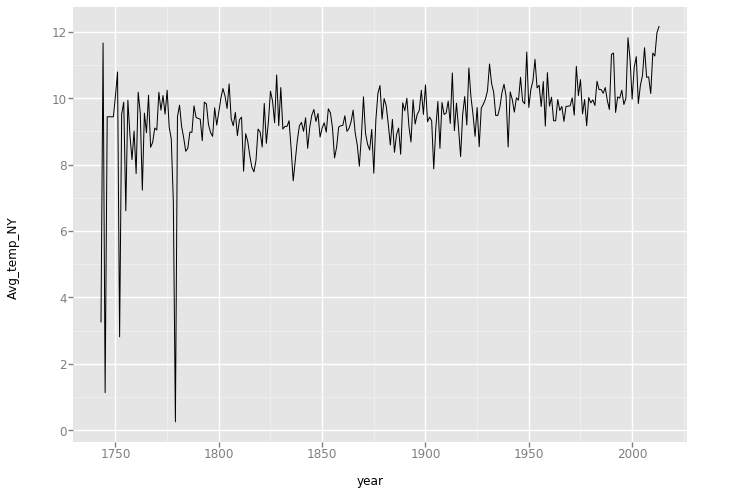

```python
ggplot(city_data,aes(x='year', y='Avg_temp_NY'))+ geom_line()
```

The city_data average temperature of NY looks parallel with average global temperature.

### Moving Average City Data- New York

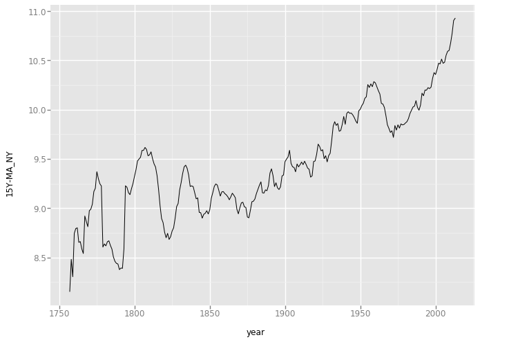

```python
#Moving Average
city_data["15Y-MA_NY"]=pd.rolling_mean(city_data['Avg_temp_NY'],window=15)

ggplot(city_data, aes(x='year',y='15Y-MA_NY')) + geom_line()
```

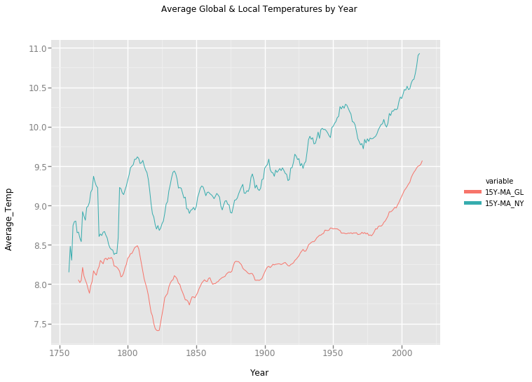

```python
# Merging the dataset together
New_data=city_data.merge(global_data, right_on='year',left_on='year',how='outer')

#Selecting columns to be used
New_data=New_data[['year','15Y-MA_NY','15Y-MA_GL']]

#Melted the data to get all variables in one line
New_data_df=pd.melt(New_data,id_vars='year')

#visualization
ggplot(New_data_df, aes(x='year',y='value',color='variable'))  + \
    geom_line() + \
   ggtitle('Average Global & Local Temperatures by Year') + xlab('Year') + ylab('Average_Temp')

##Renaming and Dropping unwanted variables
#global_data=global_data.drop(['5Y-MA','20Y-MA','30Y-MA','50Y-MA'], axis=1)
#New_data=city_data.merge(global_data, right_on='year',left_on='year',how='outer')
```

### Adding City Data-Munich

```python
#Reading the dataset
Munich_data=pd.read_csv('Munich_data.csv')

# Renaming the column names to reduce confusions
Munich_data=Munich_data.rename(columns={'avg_temp':'Avg_temp_Munich'})

# Checking if for NULL Values in columns
Munich_data['Avg_temp_Munich'].isnull().sum().sum()

#Drop Columns
Munich_data.drop(['city',], axis=1)

# Replacing Null values with Averge mean
Munich_data['Avg_temp_Munich'].fillna(Munich_data['Avg_temp_Munich'].mean(),inplace=True)

#Munich_data.head()
```

```python
#Moving Average
Munich_data["15Y-MA_MU"]=pd.rolling_mean(Munich_data['Avg_temp_Munich'],window=15)

#ggplot(Munich_data, aes(x='year',y="15Y-MA_MU")) + geom_line()
```

### Merging Global with New York and Munich dataset

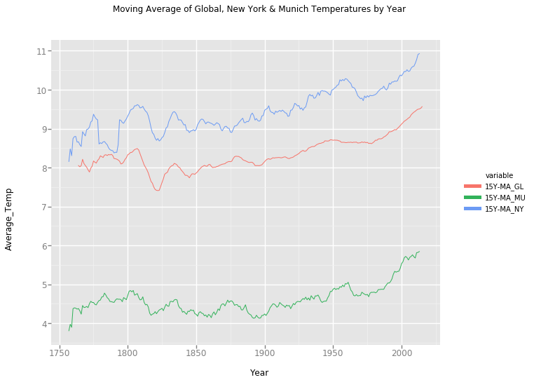

```python
#Merging the Global and New York datasframe with Munich
exmpl_data=Munich_data.merge(New_data, right_on='year',left_on='year',how='outer')

## Highlighting the only columns to be used in this model
exmpl_data=exmpl_data[['year','15Y-MA_NY','15Y-MA_GL','15Y-MA_MU']]

#Melted the data to get all variables in one line.
exmpl_data_df=pd.melt(exmpl_data,id_vars='year')

#visualization
ggplot(exmpl_data_df, aes(x='year',y='value',color='variable'))  + \
    geom_line()+\
   ggtitle('Moving Average of Global, New York & Munich Temperatures by Year') + xlab('Year') + ylab('Average_Temp')
```

By adding a new variable to our visualization, it now tells us a different story about our trend. But it still remains consistant with global and New York trends specialy from 1950s-2000s, the average temperature is in fact rising. Do note, if other city data were added to our model, then we would have a true story of their weight towards the global average temperature. Thus, the climate from different regions may vary based on their average temperature, but the buttom line obersavation is that the average temperate is rising on an continous slope, meaning the world is getting hotter.

### Insights & Observation

Similarities Global vs. My Local:

1. Parallel Moving Average.
2. The Up/Down slopes have similar trends and consistant.
3. Global and Local average temperature is on the rise.

Differences Global vs. My Local:

1. Based on the year of 1870-1900, the slopes appear to have an different trends towards one another.
2. The AVG Temperature of local and global are different based on its scaling.

# Sources:

http://pandas.pydata.org/pandas-docs/stable/